# Titanic data analysis

```python
#import necessary libraries
import pandas as pd
import numpy as np
import matplotlib.pyplot as plt
import seaborn as sns
%pylab inline
```

*Read titanic data file and create a dataframe*

```python
titanic_df = pd.read_csv('titanic-data.csv')
```

*Review the data elements and structure*

```python
titanic_df.info()
```

```
<class 'pandas.core.frame.DataFrame'>
RangeIndex: 891 entries, 0 to 890
Data columns (total 12 columns):
PassengerId    891 non-null int64
Survived       891 non-null int64
Pclass         891 non-null int64
Name           891 non-null object
Sex            891 non-null object
Age            714 non-null float64
SibSp          891 non-null int64
Parch          891 non-null int64
Ticket         891 non-null object
Fare           891 non-null float64
Cabin          204 non-null object
Embarked       889 non-null object
dtypes: float64(2), int64(5), object(5)
memory usage: 66.2+ KB
```

The following are the VARIABLE DESCRIPTIONS from Kaggle: survival Survival (0 = No; 1 = Yes) pclass Passenger Class (1 = 1st; 2 = 2nd; 3 = 3rd) name Name sex Sex age Age sibsp Number of Siblings/Spouses Aboard parch Number of Parents/Children Aboard ticket Ticket Number fare Passenger Fare cabin Cabin embarked Port of Embarkation (C = Cherbourg; Q = Queenstown; S = Southampton)

# Questions

Based on the given data, we can explore what variables/factors influence the survival rates? We can look at some specific pointed questions 1. Is sex a factor in survival rates?. 2. Is passenger class a factor in survival rates? 3. Do class and sex together made a difference in the survival? 4. Number of siblings/spouse on board made a difference in survival?*Select only the columns that will be useful for analysis and create a new dataframe*

```python
titanic = titanic_df[['PassengerId','Survived','Pclass','Sex','Age','SibSp','Fare','Parch']]
titanic.describe()
```

|  | PassengerId | Survived | Pclass | Age | SibSp | Fare | Parch |
| --- | --- | --- | --- | --- | --- | --- | --- |
| count | 891.000000 | 891.000000 | 891.000000 | 714.000000 | 891.000000 | 891.000000 | 891.000000 |
| mean | 446.000000 | 0.383838 | 2.308642 | 29.699118 | 0.523008 | 32.204208 | 0.381594 |
| std | 257.353842 | 0.486592 | 0.836071 | 14.526497 | 1.102743 | 49.693429 | 0.806057 |
| min | 1.000000 | 0.000000 | 1.000000 | 0.420000 | 0.000000 | 0.000000 | 0.000000 |
| 25% | 223.500000 | 0.000000 | 2.000000 | 20.125000 | 0.000000 | 7.910400 | 0.000000 |
| 50% | 446.000000 | 0.000000 | 3.000000 | 28.000000 | 0.000000 | 14.454200 | 0.000000 |
| 75% | 668.500000 | 1.000000 | 3.000000 | 38.000000 | 1.000000 | 31.000000 | 0.000000 |
| max | 891.000000 | 1.000000 | 3.000000 | 80.000000 | 8.000000 | 512.329200 | 6.000000 |

# Data wrangling

*Age is missing for 177 records. Dropping that many records, will significantly reduce the sample size for the data analysis. Instead filling the values with mean age is a better option in this case.*

```python
titanic.loc[:,'Age'] = titanic.loc[:,'Age'].fillna(titanic.Age.mean())
```

*Create Age bins and add Age_group column to help classify ages into different buckets*

```python
bins = [0,13, 25, 45, 65, 85]
group_names = ['Child', 'Young Adult', 'Adult', 'Middle Age', 'Senior']
titanic.loc[:,'Age_group'] = pd.cut(titanic['Age'], bins, labels=group_names)
titanic.info()
```

```
<class 'pandas.core.frame.DataFrame'>
RangeIndex: 891 entries, 0 to 890
Data columns (total 9 columns):
PassengerId    891 non-null int64
Survived       891 non-null int64
Pclass         891 non-null int64
Sex            891 non-null object
Age            891 non-null float64
SibSp          891 non-null int64
Fare           891 non-null float64
Parch          891 non-null int64
Age_group      891 non-null category
dtypes: category(1), float64(2), int64(5), object(1)
memory usage: 53.1+ KB
```

*Add new column - sex_indicator which is an integer value that can be used to evaluate correlation between Sex and Survival.

```python
def add_sex_indicator(Sex):
    if (Sex == 'female'):
        Sex_indicator = 1
    else:
        Sex_indicator = 2
    return Sex_indicator

titanic.loc[:,'Sex_indicator'] = titanic['Sex'].apply(add_sex_indicator)
```

```python
#Verify all the data looks as expected after data wrangling
titanic.tail(4)
```

|  | PassengerId | Survived | Pclass | Sex | Age | SibSp | Fare | Parch | Age_group | Sex_indicator |
| --- | --- | --- | --- | --- | --- | --- | --- | --- | --- | --- |
| 887 | 888 | 1 | 1 | female | 19.000000 | 0 | 30.00 | 0 | Young Adult | 1 |
| 888 | 889 | 0 | 3 | female | 29.699118 | 1 | 23.45 | 2 | Adult | 1 |
| 889 | 890 | 1 | 1 | male | 26.000000 | 0 | 30.00 | 0 | Adult | 2 |
| 890 | 891 | 0 | 3 | male | 32.000000 | 0 | 7.75 | 0 | Adult | 2 |

# Data Analysis

Let us look at some basics on what type of people on board and how many survived

```python
# Printing counts
print ('Total number of passngers onboard {}'.format(titanic['PassengerId'].count()))
print ('Total number of passngers survived {}'.format(titanic[(titanic.Survived==1)]['PassengerId'].count()))
print ('Male passengers onboard {}'.format(titanic[(titanic.Sex=='male')]['PassengerId'].count()))
print ('Male passngers survived {}'.format(titanic[(titanic.Sex=='male') & (titanic.Survived==1)]['PassengerId'].count()))
print ('Female passngers onboard {}'.format(titanic[(titanic.Sex=='female')]['PassengerId'].count()))
print ('Female passngers survived {}'.format(titanic[(titanic.Sex=='female') & (titanic.Survived==1)]['PassengerId'].count()))
print ('Total children under thirteen {}'.format(titanic[(titanic.Age < 13)]['PassengerId'].count()))
print ('Children under thirteen survived {}'.format(titanic[(titanic.Age < 13)&(titanic.Survived==1)]['PassengerId'].count()))
```

```
Total number of passngers onboard 891
Total number of passngers survived 342
Male passengers onboard 577
Male passngers survived 109
Female passngers onboard 314
Female passngers survived 233
Total children under thirteen 69
Children under thirteen survived 40
```

*Let us explore mean survival rates by sex, Age, Pclass and SibSp*

```python
#use groupby for grouping and exploration
Sex_grouping = titanic.groupby(['Sex'])['Survived'].mean().sort_values()
Age_grouping= titanic.groupby(['Age_group'])['Survived'].mean().sort_values()
Pclass_grouping = titanic.groupby(['Pclass'])['Survived'].mean().sort_values()
SibSp_grouping = titanic.groupby(['SibSp'])['Survived'].mean().sort_values()
print ('Mean survival rates by {}'.format(Sex_grouping))
print''
print ('Mean survival rates by {}'.format(Age_grouping))
print ''
print ('Mean survival rates by {}'.format(Pclass_grouping))
print ''
print ('Mean survival rates by {}'.format(SibSp_grouping))
```

```
Mean survival rates by Sex
male      0.188908
female    0.742038
Name: Survived, dtype: float64

Mean survival rates by Age_group
Senior         0.125000
Young Adult    0.356522
Adult          0.369610
Middle Age     0.389474
Child          0.591549
Name: Survived, dtype: float64

Mean survival rates by Pclass
3    0.242363
2    0.472826
1    0.629630
Name: Survived, dtype: float64

Mean survival rates by SibSp
5    0.000000
8    0.000000
4    0.166667
3    0.250000
0    0.345395
2    0.464286
1    0.535885
Name: Survived, dtype: float64
```

The above data shows: 1. Females have a much higher survival rate than males 2. Children below 13 have a better survival rate than other age groups 3. First class passengers have much higher survival rates than 3rd class passengers 4. Having one/two siblings/spouse onboard increased the survival rate. However as the number increased to three or four siblings, it reduced the chnce of survival. A quick look to get an idea what variables are correlated.

```python
titanic.corr()
```

|  | PassengerId | Survived | Pclass | Age | SibSp | Fare | Parch | Sex_indicator |
| --- | --- | --- | --- | --- | --- | --- | --- | --- |
| PassengerId | 1.000000 | -0.005007 | -0.035144 | 0.033207 | -0.057527 | 0.012658 | -0.001652 | 0.042939 |
| Survived | -0.005007 | 1.000000 | -0.338481 | -0.069809 | -0.035322 | 0.257307 | 0.081629 | -0.543351 |
| Pclass | -0.035144 | -0.338481 | 1.000000 | -0.331339 | 0.083081 | -0.549500 | 0.018443 | 0.131900 |
| Age | 0.033207 | -0.069809 | -0.331339 | 1.000000 | -0.232625 | 0.091566 | -0.179191 | 0.084153 |
| SibSp | -0.057527 | -0.035322 | 0.083081 | -0.232625 | 1.000000 | 0.159651 | 0.414838 | -0.114631 |
| Fare | 0.012658 | 0.257307 | -0.549500 | 0.091566 | 0.159651 | 1.000000 | 0.216225 | -0.182333 |
| Parch | -0.001652 | 0.081629 | 0.018443 | -0.179191 | 0.414838 | 0.216225 | 1.000000 | -0.245489 |
| Sex_indicator | 0.042939 | -0.543351 | 0.131900 | 0.084153 | -0.114631 | -0.182333 | -0.245489 | 1.000000 |

# Visualization

Heatmap for visualization of variable correlation

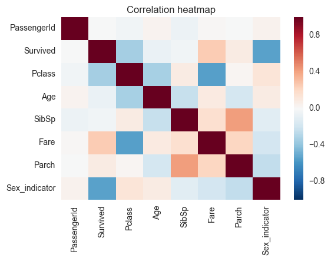

```python
corr = titanic.corr()
sns.heatmap(corr,
            xticklabels=corr.columns.values,
            yticklabels=corr.columns.values)
plt.title("Correlation heatmap")
```

Sex_indicator & Passenger class(of course "Fare") show a stronger correlation to the variable Survived

```python
#Stacked Histogram to visualize passenger ages and their survival
```

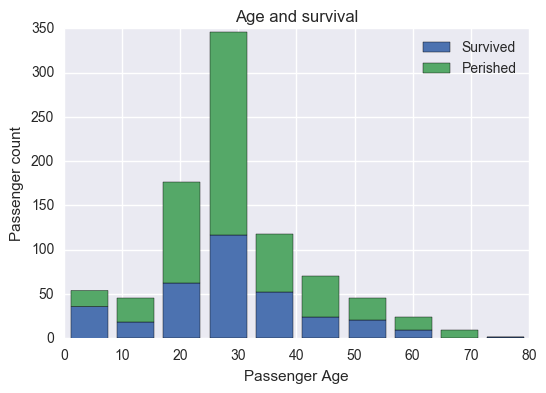

```python
Survived = titanic["Age"][titanic["Survived"] == 1]
Not_survived = titanic["Age"][titanic["Survived"] == 0]
plt.hist([Survived, Not_survived],stacked=True,
label=["Survived","Perished"]
)
plt.legend()
plt.title("Age and survival")
plt.xlabel("Passenger Age")
plt.ylabel("Passenger count")
```

*Above visuablization clearly shows that most people onboard are in the age groups between 20 and 40* *In the next graph let us visualize mean survival rate by Passenger class and sex

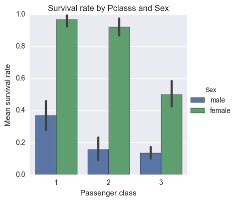

```python
Pclass_plot = sns.factorplot('Pclass','Survived', data = titanic, kind = 'bar', hue='Sex')
sns.plt.title('Survival rate by Pclasss and Sex')
Pclass_plot.set_axis_labels('Passenger class', 'Mean survival rate')
```

1. The above bar graph clearly shows females had significant advantage over males in survival. Even the females in the third class had better survival chance than males in the first class. 2. The next factor that influenced was the passenger class. 3. The lowest survival chance was for the males in third class.*The next graph we will visualize mean survival rate by age group*

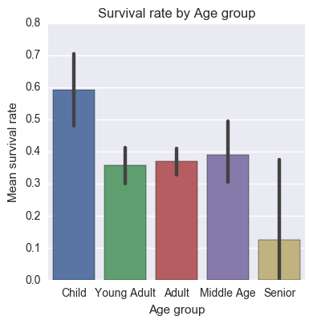

```python
Age_plot = sns.factorplot('Age_group','Survived', data = titanic, kind = 'bar')
Age_plot.set_axis_labels('Age group', 'Mean survival rate')
sns.plt.title('Survival rate by Age group')
```

*Based on the above graph, there is a better chance of survival for children when compared to other age groups. Seniors have the lowest chance of survival**In the below graph let us explore survival rate by number of siblings/spouse on board*

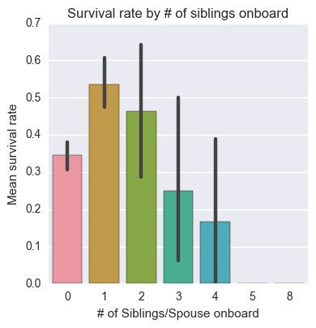

```python
SibSp_plot = sns.factorplot('SibSp','Survived', data = titanic, kind = 'bar')
SibSp_plot.set_axis_labels('# of Siblings/Spouse onboard', 'Mean survival rate')
sns.plt.title('Survival rate by # of siblings onboard')
```

1. Above graph shows surival rate was higher for people with one sibling/spouse on board. Survival rate gradually decreased with the increase in number of siblings on board. This probably could be due to family members didn't want to leave the other members behind and get on a life boat for their own safety. *Using below graph let us visuablize the population density by Age and sex in terms of their survival*

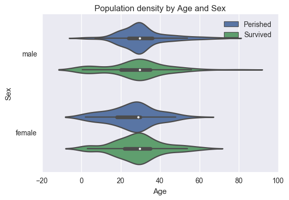

```python
ax = sns.violinplot(y="Sex", x="Age", hue="Survived", data=titanic)
plt.title("Population density by Age and Sex")
handles, _ = ax.get_legend_handles_labels()
plt.legend(handles, ['Perished', 'Survived'], title='')
```

*The above visualization shows most of passengers are in the age geroup of 20 to 40. And also the density of males survived is less than density of males perished.

# Statistical Analysis

Statistical analysis will be a good way to test and confirm our hypothesis Use the chi-square test for independence to determine whether there is a significant relationship between two categorical variables Significance level. Often, researchers choose significance levels equal to 0.01, 0.05, or 0.10; but any value between 0 and 1 can be used. Significance level for these tests will be 0.05 Null hypothesis - Passenger Sex has no influence on survival rate Alternate hypothesis -Survival rate is influenced by Passenger Sex

```python
# Chi-test for Sex and Survived variables
import scipy.stats as scs
tabulation = pd.crosstab([titanic['Survived']], titanic['Sex'])
chi2, p, ddof, expected = scs.chi2_contingency(tabulation.values )
msg = "Test Statistic: {}\np-value: {}\nDegrees of Freedom: {}\n"
print( msg.format( chi2, p, ddof ) )
print( expected )
```

```
Test Statistic: 260.717020167
p-value: 1.19735706278e-58
Degrees of Freedom: 1

[[ 193.47474747  355.52525253]
 [ 120.52525253  221.47474747]]
```

Based on the above test and 0.05 significance level probability is very low and null hypothesis will be rejectedNext test will be for Passenger class and survival rate Null hypothesis - Passenger class has no influence on survival rate Alternate hypothesis -Survival rate is influenced by Passenger class

```python
# Chi-test for Pclass and Survived variables
import scipy.stats as scs
tabulation = pd.crosstab([titanic['Survived']], titanic['Pclass'])
chi2, p, ddof, expected = scs.chi2_contingency(tabulation.values )
msg = "Test Statistic: {}\np-value: {}\nDegrees of Freedom: {}\n"
print( msg.format( chi2, p, ddof ) )
print( expected )
```

```
Test Statistic: 102.888988757
p-value: 4.5492517113e-23
Degrees of Freedom: 2

[[ 133.09090909  113.37373737  302.53535354]
 [  82.90909091   70.62626263  188.46464646]]
```

Based on the above test and 0.05 significance level probability is very low and null hypothesis will be rejected

# Conclusion

Based on the analysis conducted above, and considering the titanic data set as a sample, the following conclusions can be drawn for the population (for similar incidents). 1. Females have a significantly better chance of survival over men. 2. Passengers of the 1st class have better chance of survival over 2nd class, and 2nd class passengers over 3rd class. 3. Children and seniors have the best and worst chances of survival respectively. Limitations: -The conclusions are based on one sample(titanic) dataset. Correlation of the variables in the analysis doesn't imply causation. -Only controlled experiments will lead to causation. -Age was missing for 177 records and it was filled with the mean Age. This might have caused a slight impact on the analysis/conclusions based on Age - Most of the titanic data is collected from survivors and there might be some bias in the information they provided. Of course dead people can't be surveyed for their information.